# examples_1203

If we start with a generic quadratic equation and use [completing the square](https://en.wikipedia.org/wiki/Completing_the_square) to solve it, we can derive the [quadratic formula](https://en.wikipedia.org/wiki/Quadratic_formula):

- If $ax^2+bx+c=0$, then
  $$x~=~\frac{-b \pm
  \sqrt{b^2-4ac}}{2a}$$

Use the quadratic formula to find both solutions (rounded to the nearest hundredth) to the equation below.

$$9x^2+8x-2~=~0$$

- $x=$
- or
- $x=$

Identify the parameters.

- The quadratic coefficient: $a=9$
- The linear coefficient: $b=8$
- The constant: $c=-2$

Plug the numbers into the quadratic formula.

$$x~=~\frac{-(8)\pm
\sqrt{(8)^2-4(9)(-2)}}{2(9)}$$

Simplify.

$$x~=~\frac{-8\pm \sqrt{64
+72}}{18}$$

Simplify MORE.

$$x~=~\frac{-8\pm
\sqrt{136}}{18}$$

Now, plug both expressions into a calculator.

$$x~=~\frac{-8-
\sqrt{136}}{18}~=~-1.092328 ~\approx -1.09$$

OR

$$x~=~\frac{-8+
\sqrt{136}}{18}~=~0.2034391 ~\approx 0.2$$

If you are using a basic (one-line) scientific calculator, you can type the expressions like:

`(-8-sqrt(136))/(18)`

`(-8+sqrt(136))/(18)`

Or maybe...

`(-8-√(136))/(18)`

`(-8+√(136))/(18)`

If we start with a generic quadratic equation and use [completing the square](https://en.wikipedia.org/wiki/Completing_the_square) to solve it, we can derive the [quadratic formula](https://en.wikipedia.org/wiki/Quadratic_formula):

- If $ax^2+bx+c=0$, then
  $$x~=~\frac{-b \pm
  \sqrt{b^2-4ac}}{2a}$$

Use the quadratic formula to find both solutions (rounded to the nearest hundredth) to the equation below.

$$-6x^2-2x+10~=~0$$

- $x=$
- or
- $x=$

Identify the parameters.

- The quadratic coefficient: $a=-6$
- The linear coefficient: $b=-2$
- The constant: $c=10$

Plug the numbers into the quadratic formula.

$$x~=~\frac{-(-2)\pm
\sqrt{(-2)^2-4(-6)(10)}}{2(-6)}$$

Simplify.

$$x~=~\frac{2\pm \sqrt{4
+240}}{-12}$$

Simplify MORE.

$$x~=~\frac{2\pm
\sqrt{244}}{-12}$$

Now, plug both expressions into a calculator.

$$x~=~\frac{2-
\sqrt{244}}{-12}~=~1.1350416 ~\approx 1.14$$

OR

$$x~=~\frac{2+
\sqrt{244}}{-12}~=~-1.4683749 ~\approx -1.47$$

If you are using a basic (one-line) scientific calculator, you can type the expressions like:

`(2-sqrt(244))/(-12)`

`(2+sqrt(244))/(-12)`

Or maybe...

`(2-√(244))/(-12)`

`(2+√(244))/(-12)`

If we start with a generic quadratic equation and use [completing the square](https://en.wikipedia.org/wiki/Completing_the_square) to solve it, we can derive the [quadratic formula](https://en.wikipedia.org/wiki/Quadratic_formula):

- If $ax^2+bx+c=0$, then
  $$x~=~\frac{-b \pm
  \sqrt{b^2-4ac}}{2a}$$

Use the quadratic formula to find both solutions (rounded to the nearest hundredth) to the equation below.

$$-12x^2-2x+5~=~0$$

- $x=$
- or
- $x=$

Identify the parameters.

- The quadratic coefficient: $a=-12$
- The linear coefficient: $b=-2$
- The constant: $c=5$

Plug the numbers into the quadratic formula.

$$x~=~\frac{-(-2)\pm
\sqrt{(-2)^2-4(-12)(5)}}{2(-12)}$$

Simplify.

$$x~=~\frac{2\pm \sqrt{4
+240}}{-24}$$

Simplify MORE.

$$x~=~\frac{2\pm
\sqrt{244}}{-24}$$

Now, plug both expressions into a calculator.

$$x~=~\frac{2-
\sqrt{244}}{-24}~=~0.5675208 ~\approx 0.57$$

OR

$$x~=~\frac{2+
\sqrt{244}}{-24}~=~-0.7341875 ~\approx -0.73$$

If you are using a basic (one-line) scientific calculator, you can type the expressions like:

`(2-sqrt(244))/(-24)`

`(2+sqrt(244))/(-24)`

Or maybe...

`(2-√(244))/(-24)`

`(2+√(244))/(-24)`

If we start with a generic quadratic equation and use [completing the square](https://en.wikipedia.org/wiki/Completing_the_square) to solve it, we can derive the [quadratic formula](https://en.wikipedia.org/wiki/Quadratic_formula):

- If $ax^2+bx+c=0$, then
  $$x~=~\frac{-b \pm
  \sqrt{b^2-4ac}}{2a}$$

Use the quadratic formula to find both solutions (rounded to the nearest hundredth) to the equation below.

$$10x^2+5x-9~=~0$$

- $x=$
- or
- $x=$

Identify the parameters.

- The quadratic coefficient: $a=10$
- The linear coefficient: $b=5$
- The constant: $c=-9$

Plug the numbers into the quadratic formula.

$$x~=~\frac{-(5)\pm
\sqrt{(5)^2-4(10)(-9)}}{2(10)}$$

Simplify.

$$x~=~\frac{-5\pm \sqrt{25
+360}}{20}$$

Simplify MORE.

$$x~=~\frac{-5\pm
\sqrt{385}}{20}$$

Now, plug both expressions into a calculator.

$$x~=~\frac{-5-
\sqrt{385}}{20}~=~-1.2310708 ~\approx -1.23$$

OR

$$x~=~\frac{-5+
\sqrt{385}}{20}~=~0.7310708 ~\approx 0.73$$

If you are using a basic (one-line) scientific calculator, you can type the expressions like:

`(-5-sqrt(385))/(20)`

`(-5+sqrt(385))/(20)`

Or maybe...

`(-5-√(385))/(20)`

`(-5+√(385))/(20)`

If we start with a generic quadratic equation and use [completing the square](https://en.wikipedia.org/wiki/Completing_the_square) to solve it, we can derive the [quadratic formula](https://en.wikipedia.org/wiki/Quadratic_formula):

- If $ax^2+bx+c=0$, then
  $$x~=~\frac{-b \pm
  \sqrt{b^2-4ac}}{2a}$$

Use the quadratic formula to find both solutions (rounded to the nearest hundredth) to the equation below.

$$12x^2+11x-5~=~0$$

- $x=$
- or
- $x=$

Identify the parameters.

- The quadratic coefficient: $a=12$
- The linear coefficient: $b=11$
- The constant: $c=-5$

Plug the numbers into the quadratic formula.

$$x~=~\frac{-(11)\pm
\sqrt{(11)^2-4(12)(-5)}}{2(12)}$$

Simplify.

$$x~=~\frac{-11\pm \sqrt{121
+240}}{24}$$

Simplify MORE.

$$x~=~\frac{-11\pm
\sqrt{361}}{24}$$

Now, plug both expressions into a calculator.

$$x~=~\frac{-11- \sqrt{361}}{24}~=~-1.25
~\approx -1.25$$

OR

$$x~=~\frac{-11+
\sqrt{361}}{24}~=~0.3333333 ~\approx 0.33$$

If you are using a basic (one-line) scientific calculator, you can type the expressions like:

`(-11-sqrt(361))/(24)`

`(-11+sqrt(361))/(24)`

Or maybe...

`(-11-√(361))/(24)`

`(-11+√(361))/(24)`

If we start with a generic quadratic equation and use [completing the square](https://en.wikipedia.org/wiki/Completing_the_square) to solve it, we can derive the [quadratic formula](https://en.wikipedia.org/wiki/Quadratic_formula):

- If $ax^2+bx+c=0$, then
  $$x~=~\frac{-b \pm
  \sqrt{b^2-4ac}}{2a}$$

Use the quadratic formula to find both solutions (rounded to the nearest hundredth) to the equation below.

$$12x^2-8x-2~=~0$$

- $x=$
- or
- $x=$

Identify the parameters.

- The quadratic coefficient: $a=12$
- The linear coefficient: $b=-8$
- The constant: $c=-2$

Plug the numbers into the quadratic formula.

$$x~=~\frac{-(-8)\pm
\sqrt{(-8)^2-4(12)(-2)}}{2(12)}$$

Simplify.

$$x~=~\frac{8\pm \sqrt{64
+96}}{24}$$

Simplify MORE.

$$x~=~\frac{8\pm
\sqrt{160}}{24}$$

Now, plug both expressions into a calculator.

$$x~=~\frac{8-
\sqrt{160}}{24}~=~-0.1937129 ~\approx -0.19$$

OR

$$x~=~\frac{8+ \sqrt{160}}{24}~=~0.8603796
~\approx 0.86$$

If you are using a basic (one-line) scientific calculator, you can type the expressions like:

`(8-sqrt(160))/(24)`

`(8+sqrt(160))/(24)`

Or maybe...

`(8-√(160))/(24)`

`(8+√(160))/(24)`

If we start with a generic quadratic equation and use [completing the square](https://en.wikipedia.org/wiki/Completing_the_square) to solve it, we can derive the [quadratic formula](https://en.wikipedia.org/wiki/Quadratic_formula):

- If $ax^2+bx+c=0$, then
  $$x~=~\frac{-b \pm
  \sqrt{b^2-4ac}}{2a}$$

Use the quadratic formula to find both solutions (rounded to the nearest hundredth) to the equation below.

$$-3x^2-6x+2~=~0$$

- $x=$
- or
- $x=$

Identify the parameters.

- The quadratic coefficient: $a=-3$
- The linear coefficient: $b=-6$
- The constant: $c=2$

Plug the numbers into the quadratic formula.

$$x~=~\frac{-(-6)\pm
\sqrt{(-6)^2-4(-3)(2)}}{2(-3)}$$

Simplify.

$$x~=~\frac{6\pm \sqrt{36
+24}}{-6}$$

Simplify MORE.

$$x~=~\frac{6\pm
\sqrt{60}}{-6}$$

Now, plug both expressions into a calculator.

$$x~=~\frac{6- \sqrt{60}}{-6}~=~0.2909944
~\approx 0.29$$

OR

$$x~=~\frac{6+ \sqrt{60}}{-6}~=~-2.2909944
~\approx -2.29$$

If you are using a basic (one-line) scientific calculator, you can type the expressions like:

`(6-sqrt(60))/(-6)`

`(6+sqrt(60))/(-6)`

Or maybe...

`(6-√(60))/(-6)`

`(6+√(60))/(-6)`

If we start with a generic quadratic equation and use [completing the square](https://en.wikipedia.org/wiki/Completing_the_square) to solve it, we can derive the [quadratic formula](https://en.wikipedia.org/wiki/Quadratic_formula):

- If $ax^2+bx+c=0$, then
  $$x~=~\frac{-b \pm
  \sqrt{b^2-4ac}}{2a}$$

Use the quadratic formula to find both solutions (rounded to the nearest hundredth) to the equation below.

$$-7x^2+6x+10~=~0$$

- $x=$
- or
- $x=$

Identify the parameters.

- The quadratic coefficient: $a=-7$
- The linear coefficient: $b=6$
- The constant: $c=10$

Plug the numbers into the quadratic formula.

$$x~=~\frac{-(6)\pm
\sqrt{(6)^2-4(-7)(10)}}{2(-7)}$$

Simplify.

$$x~=~\frac{-6\pm \sqrt{36
+280}}{-14}$$

Simplify MORE.

$$x~=~\frac{-6\pm
\sqrt{316}}{-14}$$

Now, plug both expressions into a calculator.

$$x~=~\frac{-6-
\sqrt{316}}{-14}~=~1.6983135 ~\approx 1.7$$

OR

$$x~=~\frac{-6+
\sqrt{316}}{-14}~=~-0.8411706 ~\approx -0.84$$

If you are using a basic (one-line) scientific calculator, you can type the expressions like:

`(-6-sqrt(316))/(-14)`

`(-6+sqrt(316))/(-14)`

Or maybe...

`(-6-√(316))/(-14)`

`(-6+√(316))/(-14)`

A rectangle's height is 2 meters longer than its width. The area is 40 square meters. In meters, what is the height? (*Answers should be accurate within $\pm 0.1$ meters*)

Let $x$ represent the height. The width is $x-{2}$. The area of a rectangle equals the product of height times width.

$$40~=~x\cdot (x-{2})$$

Distribute the multiplication of $x$ to the terms in parentheses.

$$40~=~x^{2}-{2}x$$

Subtract 40 from both sides.

$$0~=~x^{2}-{2}x-{40}$$

Now the right side of the equation is in standard form. We can identify $a$, $b$, and $c$ in order to use the quadratic formula.

$$a=1$$
$$b=-2$$
$$c=-40$$

Remember the formula.

$$x~=~\frac{-b\pm
\sqrt{b^2-4ac}}{2a}$$

Plug in the coefficients.

$$x~=~\frac{-(-2)\pm
\sqrt{(-2)^2-4(1)(-40)}}{2(1)}$$

Simplify.

$$x~=~\frac{2\pm
\sqrt{{4}+{160}}}{2}$$

Simplify more.

$$x~=~\frac{2\pm
\sqrt{164}}{2}$$

Simplify more.

$$x~=~\frac{2\pm
2\sqrt{41}}{2}$$

Simplify more.
$$x~=~1\pm
\sqrt{41}$$

This (or, honestly, one of the earlier, less simplified expressions) can be put into a calculator to get the two possible values for $x$ as decimal approximations. We are only interested in the positive solution.

$$x=7.4031242$$

A rectangle's height is 2 meters longer than its width. The area is 37 square meters. In meters, what is the height? (*Answers should be accurate within $\pm 0.1$ meters*)

Let $x$ represent the height. The width is $x-{2}$. The area of a rectangle equals the product of height times width.

$$37~=~x\cdot (x-{2})$$

Distribute the multiplication of $x$ to the terms in parentheses.

$$37~=~x^{2}-{2}x$$

Subtract 37 from both sides.

$$0~=~x^{2}-{2}x-{37}$$

Now the right side of the equation is in standard form. We can identify $a$, $b$, and $c$ in order to use the quadratic formula.

$$a=1$$
$$b=-2$$
$$c=-37$$

Remember the formula.

$$x~=~\frac{-b\pm
\sqrt{b^2-4ac}}{2a}$$

Plug in the coefficients.

$$x~=~\frac{-(-2)\pm
\sqrt{(-2)^2-4(1)(-37)}}{2(1)}$$

Simplify.

$$x~=~\frac{2\pm
\sqrt{{4}+{148}}}{2}$$

Simplify more.

$$x~=~\frac{2\pm
\sqrt{152}}{2}$$

Simplify more.

$$x~=~\frac{2\pm
2\sqrt{38}}{2}$$

Simplify more.
$$x~=~1\pm
\sqrt{38}$$

This (or, honestly, one of the earlier, less simplified expressions) can be put into a calculator to get the two possible values for $x$ as decimal approximations. We are only interested in the positive solution.

$$x=7.164414$$

A rectangle's height is 4 meters longer than its width. The area is 38 square meters. In meters, what is the height? (*Answers should be accurate within $\pm 0.1$ meters*)

Let $x$ represent the height. The width is $x-{4}$. The area of a rectangle equals the product of height times width.

$$38~=~x\cdot (x-{4})$$

Distribute the multiplication of $x$ to the terms in parentheses.

$$38~=~x^{2}-{4}x$$

Subtract 38 from both sides.

$$0~=~x^{2}-{4}x-{38}$$

Now the right side of the equation is in standard form. We can identify $a$, $b$, and $c$ in order to use the quadratic formula.

$$a=1$$
$$b=-4$$
$$c=-38$$

Remember the formula.

$$x~=~\frac{-b\pm
\sqrt{b^2-4ac}}{2a}$$

Plug in the coefficients.

$$x~=~\frac{-(-4)\pm
\sqrt{(-4)^2-4(1)(-38)}}{2(1)}$$

Simplify.

$$x~=~\frac{4\pm
\sqrt{{16}+{152}}}{2}$$

Simplify more.

$$x~=~\frac{4\pm
\sqrt{168}}{2}$$

Simplify more.

$$x~=~\frac{4\pm
2\sqrt{42}}{2}$$

Simplify more.
$$x~=~2\pm
\sqrt{42}$$

This (or, honestly, one of the earlier, less simplified expressions) can be put into a calculator to get the two possible values for $x$ as decimal approximations. We are only interested in the positive solution.

$$x=8.4807407$$

A rectangle's height is 2 meters longer than its width. The area is 33 square meters. In meters, what is the height? (*Answers should be accurate within $\pm 0.1$ meters*)

Let $x$ represent the height. The width is $x-{2}$. The area of a rectangle equals the product of height times width.

$$33~=~x\cdot (x-{2})$$

Distribute the multiplication of $x$ to the terms in parentheses.

$$33~=~x^{2}-{2}x$$

Subtract 33 from both sides.

$$0~=~x^{2}-{2}x-{33}$$

Now the right side of the equation is in standard form. We can identify $a$, $b$, and $c$ in order to use the quadratic formula.

$$a=1$$
$$b=-2$$
$$c=-33$$

Remember the formula.

$$x~=~\frac{-b\pm
\sqrt{b^2-4ac}}{2a}$$

Plug in the coefficients.

$$x~=~\frac{-(-2)\pm
\sqrt{(-2)^2-4(1)(-33)}}{2(1)}$$

Simplify.

$$x~=~\frac{2\pm
\sqrt{{4}+{132}}}{2}$$

Simplify more.

$$x~=~\frac{2\pm
\sqrt{136}}{2}$$

Simplify more.

$$x~=~\frac{2\pm
2\sqrt{34}}{2}$$

Simplify more.
$$x~=~1\pm
\sqrt{34}$$

This (or, honestly, one of the earlier, less simplified expressions) can be put into a calculator to get the two possible values for $x$ as decimal approximations. We are only interested in the positive solution.

$$x=6.8309519$$

A rectangle's height is 2 meters longer than its width. The area is 46 square meters. In meters, what is the height? (*Answers should be accurate within $\pm 0.1$ meters*)

Let $x$ represent the height. The width is $x-{2}$. The area of a rectangle equals the product of height times width.

$$46~=~x\cdot (x-{2})$$

Distribute the multiplication of $x$ to the terms in parentheses.

$$46~=~x^{2}-{2}x$$

Subtract 46 from both sides.

$$0~=~x^{2}-{2}x-{46}$$

Now the right side of the equation is in standard form. We can identify $a$, $b$, and $c$ in order to use the quadratic formula.

$$a=1$$
$$b=-2$$
$$c=-46$$

Remember the formula.

$$x~=~\frac{-b\pm
\sqrt{b^2-4ac}}{2a}$$

Plug in the coefficients.

$$x~=~\frac{-(-2)\pm
\sqrt{(-2)^2-4(1)(-46)}}{2(1)}$$

Simplify.

$$x~=~\frac{2\pm
\sqrt{{4}+{184}}}{2}$$

Simplify more.

$$x~=~\frac{2\pm
\sqrt{188}}{2}$$

Simplify more.

$$x~=~\frac{2\pm
2\sqrt{47}}{2}$$

Simplify more.
$$x~=~1\pm
\sqrt{47}$$

This (or, honestly, one of the earlier, less simplified expressions) can be put into a calculator to get the two possible values for $x$ as decimal approximations. We are only interested in the positive solution.

$$x=7.8556546$$

A rectangle's width is 4 meters shorter than its height. The area is 30 square meters. In meters, what is the height? (*Answers should be accurate within $\pm 0.1$ meters*)

Let $x$ represent the height. The width is $x-{4}$. The area of a rectangle equals the product of height times width.

$$30~=~x\cdot (x-{4})$$

Distribute the multiplication of $x$ to the terms in parentheses.

$$30~=~x^{2}-{4}x$$

Subtract 30 from both sides.

$$0~=~x^{2}-{4}x-{30}$$

Now the right side of the equation is in standard form. We can identify $a$, $b$, and $c$ in order to use the quadratic formula.

$$a=1$$
$$b=-4$$
$$c=-30$$

Remember the formula.

$$x~=~\frac{-b\pm
\sqrt{b^2-4ac}}{2a}$$

Plug in the coefficients.

$$x~=~\frac{-(-4)\pm
\sqrt{(-4)^2-4(1)(-30)}}{2(1)}$$

Simplify.

$$x~=~\frac{4\pm
\sqrt{{16}+{120}}}{2}$$

Simplify more.

$$x~=~\frac{4\pm
\sqrt{136}}{2}$$

Simplify more.

$$x~=~\frac{4\pm
2\sqrt{34}}{2}$$

Simplify more.
$$x~=~2\pm
\sqrt{34}$$

This (or, honestly, one of the earlier, less simplified expressions) can be put into a calculator to get the two possible values for $x$ as decimal approximations. We are only interested in the positive solution.

$$x=7.8309519$$

A rectangle's height is 4 meters shorter than its width. The area is 43 square meters. In meters, what is the height? (*Answers should be accurate within $\pm 0.1$ meters*)

Let $x$ represent the height. The width is $x+{4}$. The area of a rectangle equals the product of height times width.

$$43~=~x\cdot (x+{4})$$

Distribute the multiplication of $x$ to the terms in parentheses.

$$43~=~x^{2}+{4}x$$

Subtract 43 from both sides.

$$0~=~x^{2}+{4}x-{43}$$

Now the right side of the equation is in standard form. We can identify $a$, $b$, and $c$ in order to use the quadratic formula.

$$a=1$$
$$b=4$$
$$c=-43$$

Remember the formula.

$$x~=~\frac{-b\pm
\sqrt{b^2-4ac}}{2a}$$

Plug in the coefficients.

$$x~=~\frac{-(4)\pm
\sqrt{(4)^2-4(1)(-43)}}{2(1)}$$

Simplify.

$$x~=~\frac{-4\pm
\sqrt{{16}+{172}}}{2}$$

Simplify more.

$$x~=~\frac{-4\pm
\sqrt{188}}{2}$$

Simplify more.

$$x~=~\frac{-4\pm
2\sqrt{47}}{2}$$

Simplify more.
$$x~=~-2\pm
\sqrt{47}$$

This (or, honestly, one of the earlier, less simplified expressions) can be put into a calculator to get the two possible values for $x$ as decimal approximations. We are only interested in the positive solution.

$$x=4.8556546$$

A rectangle's width is 4 meters longer than its height. The area is 43 square meters. In meters, what is the height? (*Answers should be accurate within $\pm 0.1$ meters*)

Let $x$ represent the height. The width is $x+{4}$. The area of a rectangle equals the product of height times width.

$$43~=~x\cdot (x+{4})$$

Distribute the multiplication of $x$ to the terms in parentheses.

$$43~=~x^{2}+{4}x$$

Subtract 43 from both sides.

$$0~=~x^{2}+{4}x-{43}$$

Now the right side of the equation is in standard form. We can identify $a$, $b$, and $c$ in order to use the quadratic formula.

$$a=1$$
$$b=4$$
$$c=-43$$

Remember the formula.

$$x~=~\frac{-b\pm
\sqrt{b^2-4ac}}{2a}$$

Plug in the coefficients.

$$x~=~\frac{-(4)\pm
\sqrt{(4)^2-4(1)(-43)}}{2(1)}$$

Simplify.

$$x~=~\frac{-4\pm
\sqrt{{16}+{172}}}{2}$$

Simplify more.

$$x~=~\frac{-4\pm
\sqrt{188}}{2}$$

Simplify more.

$$x~=~\frac{-4\pm
2\sqrt{47}}{2}$$

Simplify more.
$$x~=~-2\pm
\sqrt{47}$$

This (or, honestly, one of the earlier, less simplified expressions) can be put into a calculator to get the two possible values for $x$ as decimal approximations. We are only interested in the positive solution.

$$x=4.8556546$$

Consider the quadratic function defined below:

$$f(x)~=~-4x^2+7x+8$$

When we graph $y=f(x)$, we see there are two [roots](https://en.wikipedia.org/wiki/Zero_of_a_function) at $(r,0)$ and $(s,0)$. (The word "roots" means the same thing as "$x$-intercepts" or "zeros".)

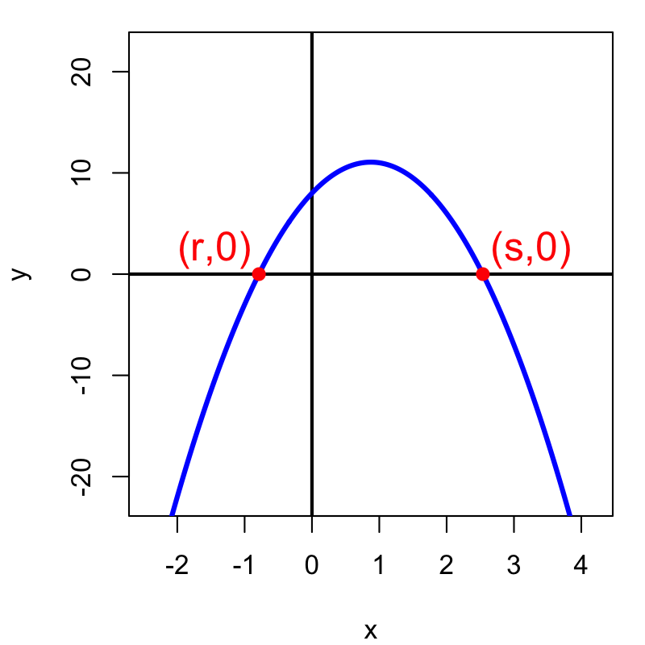

By using the [quadratic formula](https://en.wikipedia.org/wiki/Quadratic_formula), find the roots.

- $r=$
- $s=$

Identify the parameters.

- The quadratic coefficient: $a=-4$
- The linear coefficient: $b=7$
- The constant: $c=8$

The $x$-intercepts of a function are found by solving for $x$ when $f(x)=0$.

$$-4x^2+7x+8=0$$

Use the quadratic formula to solve the equation.

$$x~=~\frac{-(7)\pm
\sqrt{(7)^2-4(-4)(8)}}{2(-4)}$$

Simplify.

$$x~=~\frac{-7\pm \sqrt{49
+128}}{-8}$$

Simplify MORE.

$$x~=~\frac{-7\pm
\sqrt{177}}{-8}$$

Now, plug both expressions into a calculator.

$$x~=~\frac{-7-
\sqrt{177}}{-8}~=~2.5380168 ~\approx 2.54$$

OR

$$x~=~\frac{-7+
\sqrt{177}}{-8}~=~-0.7880168 ~\approx -0.79$$

So, $r=-0.7880168$ and $s=2.5380168$.

Consider the quadratic function defined below:

$$f(x)~=~-5x^2+11x+8$$

When we graph $y=f(x)$, we see there are two [roots](https://en.wikipedia.org/wiki/Zero_of_a_function) at $(r,0)$ and $(s,0)$. (The word "roots" means the same thing as "$x$-intercepts" or "zeros".)

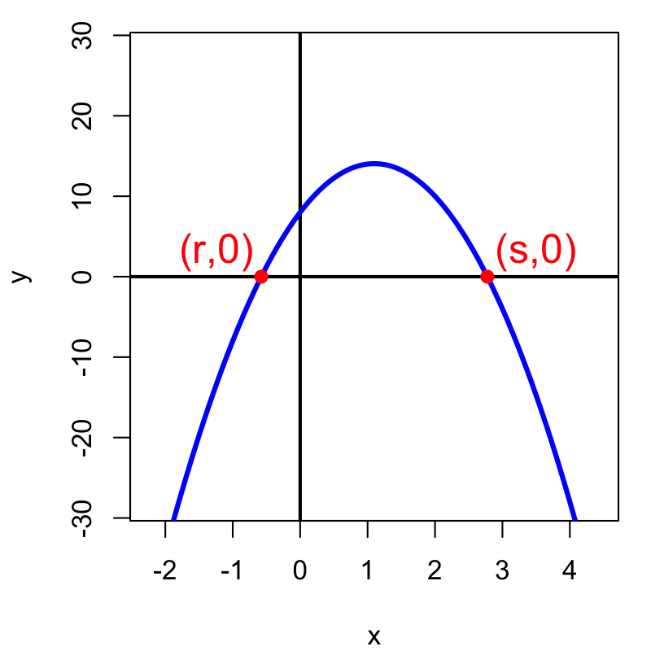

By using the [quadratic formula](https://en.wikipedia.org/wiki/Quadratic_formula), find the roots.

- $r=$
- $s=$

Identify the parameters.

- The quadratic coefficient: $a=-5$
- The linear coefficient: $b=11$
- The constant: $c=8$

The $x$-intercepts of a function are found by solving for $x$ when $f(x)=0$.

$$-5x^2+11x+8=0$$

Use the quadratic formula to solve the equation.

$$x~=~\frac{-(11)\pm
\sqrt{(11)^2-4(-5)(8)}}{2(-5)}$$

Simplify.

$$x~=~\frac{-11\pm \sqrt{121
+160}}{-10}$$

Simplify MORE.

$$x~=~\frac{-11\pm
\sqrt{281}}{-10}$$

Now, plug both expressions into a calculator.

$$x~=~\frac{-11-
\sqrt{281}}{-10}~=~2.7763055 ~\approx 2.78$$

OR

$$x~=~\frac{-11+
\sqrt{281}}{-10}~=~-0.5763055 ~\approx -0.58$$

So, $r=-0.5763055$ and $s=2.7763055$.

Consider the quadratic function defined below:

$$f(x)~=~-6x^2+4x+7$$

When we graph $y=f(x)$, we see there are two [roots](https://en.wikipedia.org/wiki/Zero_of_a_function) at $(r,0)$ and $(s,0)$. (The word "roots" means the same thing as "$x$-intercepts" or "zeros".)

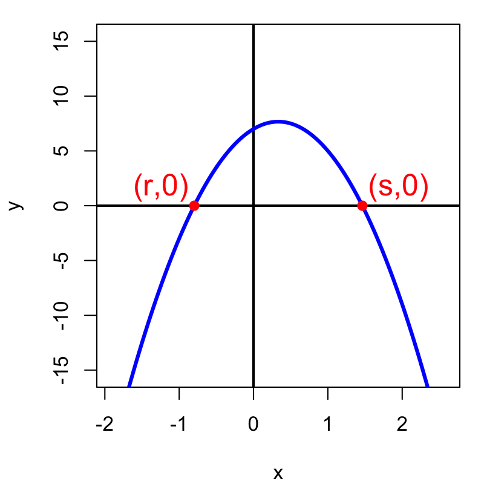

By using the [quadratic formula](https://en.wikipedia.org/wiki/Quadratic_formula), find the roots.

- $r=$
- $s=$

Identify the parameters.

- The quadratic coefficient: $a=-6$
- The linear coefficient: $b=4$
- The constant: $c=7$

The $x$-intercepts of a function are found by solving for $x$ when $f(x)=0$.

$$-6x^2+4x+7=0$$

Use the quadratic formula to solve the equation.

$$x~=~\frac{-(4)\pm
\sqrt{(4)^2-4(-6)(7)}}{2(-6)}$$

Simplify.

$$x~=~\frac{-4\pm \sqrt{16
+168}}{-12}$$

Simplify MORE.

$$x~=~\frac{-4\pm
\sqrt{184}}{-12}$$

Now, plug both expressions into a calculator.

$$x~=~\frac{-4-
\sqrt{184}}{-12}~=~1.4637217 ~\approx 1.46$$

OR

$$x~=~\frac{-4+
\sqrt{184}}{-12}~=~-0.797055 ~\approx -0.80$$

So, $r=-0.797055$ and $s=1.4637217$.

Consider the quadratic function defined below:

$$f(x)~=~6x^2-4x-7$$

When we graph $y=f(x)$, we see there are two [roots](https://en.wikipedia.org/wiki/Zero_of_a_function) at $(r,0)$ and $(s,0)$. (The word "roots" means the same thing as "$x$-intercepts" or "zeros".)

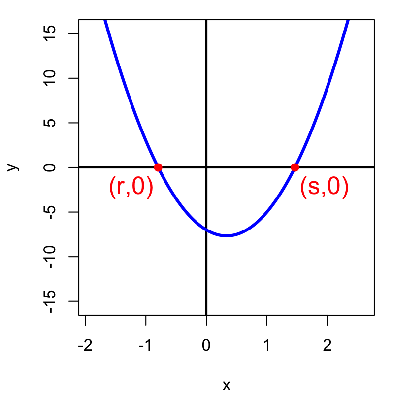

By using the [quadratic formula](https://en.wikipedia.org/wiki/Quadratic_formula), find the roots.

- $r=$
- $s=$

Identify the parameters.

- The quadratic coefficient: $a=6$
- The linear coefficient: $b=-4$
- The constant: $c=-7$

The $x$-intercepts of a function are found by solving for $x$ when $f(x)=0$.

$$6x^2-4x-7=0$$

Use the quadratic formula to solve the equation.

$$x~=~\frac{-(-4)\pm
\sqrt{(-4)^2-4(6)(-7)}}{2(6)}$$

Simplify.

$$x~=~\frac{4\pm \sqrt{16
+168}}{12}$$

Simplify MORE.

$$x~=~\frac{4\pm
\sqrt{184}}{12}$$

Now, plug both expressions into a calculator.

$$x~=~\frac{4- \sqrt{184}}{12}~=~-0.797055
~\approx -0.80$$

OR

$$x~=~\frac{4+ \sqrt{184}}{12}~=~1.4637217
~\approx 1.46$$

So, $r=-0.797055$ and $s=1.4637217$.

Consider the quadratic function defined below:

$$f(x)~=~-6x^2+8x+4$$

When we graph $y=f(x)$, we see there are two [roots](https://en.wikipedia.org/wiki/Zero_of_a_function) at $(r,0)$ and $(s,0)$. (The word "roots" means the same thing as "$x$-intercepts" or "zeros".)

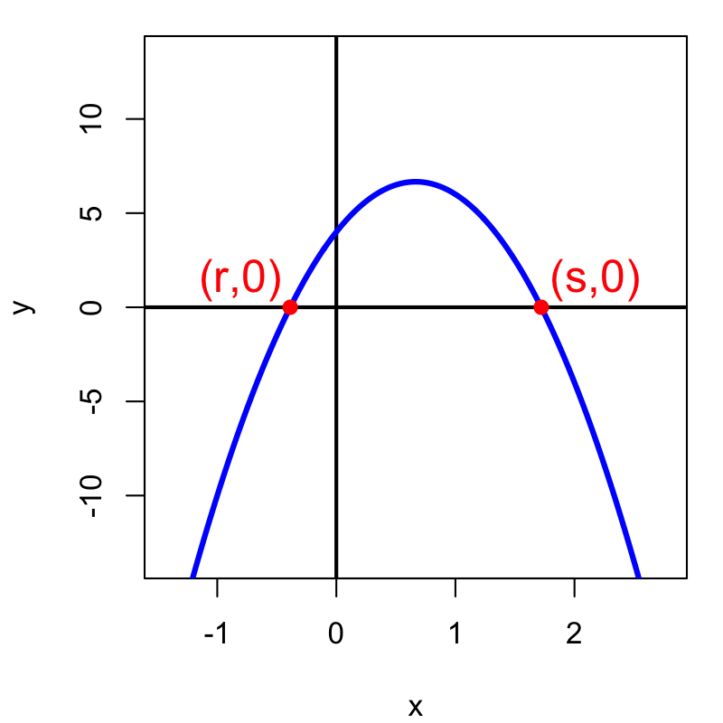

By using the [quadratic formula](https://en.wikipedia.org/wiki/Quadratic_formula), find the roots.

- $r=$
- $s=$

Identify the parameters.

- The quadratic coefficient: $a=-6$
- The linear coefficient: $b=8$
- The constant: $c=4$

The $x$-intercepts of a function are found by solving for $x$ when $f(x)=0$.

$$-6x^2+8x+4=0$$

Use the quadratic formula to solve the equation.

$$x~=~\frac{-(8)\pm
\sqrt{(8)^2-4(-6)(4)}}{2(-6)}$$

Simplify.

$$x~=~\frac{-8\pm \sqrt{64
+96}}{-12}$$

Simplify MORE.

$$x~=~\frac{-8\pm
\sqrt{160}}{-12}$$

Now, plug both expressions into a calculator.

$$x~=~\frac{-8-
\sqrt{160}}{-12}~=~1.7207592 ~\approx 1.72$$

OR

$$x~=~\frac{-8+
\sqrt{160}}{-12}~=~-0.3874259 ~\approx -0.39$$

So, $r=-0.3874259$ and $s=1.7207592$.

Consider the quadratic function defined below:

$$f(x)~=~-11x^2-5x+8$$

When we graph $y=f(x)$, we see there are two [roots](https://en.wikipedia.org/wiki/Zero_of_a_function) at $(r,0)$ and $(s,0)$. (The word "roots" means the same thing as "$x$-intercepts" or "zeros".)

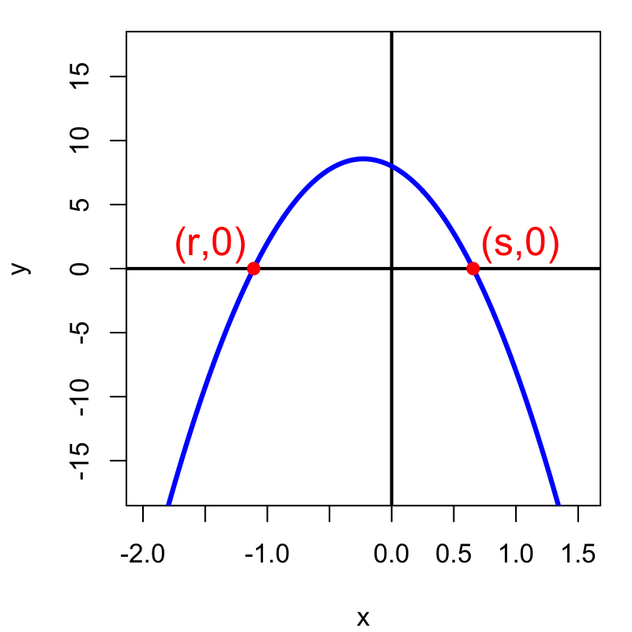

By using the [quadratic formula](https://en.wikipedia.org/wiki/Quadratic_formula), find the roots.

- $r=$
- $s=$

Identify the parameters.

- The quadratic coefficient: $a=-11$
- The linear coefficient: $b=-5$
- The constant: $c=8$

The $x$-intercepts of a function are found by solving for $x$ when $f(x)=0$.

$$-11x^2-5x+8=0$$

Use the quadratic formula to solve the equation.

$$x~=~\frac{-(-5)\pm
\sqrt{(-5)^2-4(-11)(8)}}{2(-11)}$$

Simplify.

$$x~=~\frac{5\pm \sqrt{25
+352}}{-22}$$

Simplify MORE.

$$x~=~\frac{5\pm
\sqrt{377}}{-22}$$

Now, plug both expressions into a calculator.

$$x~=~\frac{5-
\sqrt{377}}{-22}~=~0.6552949 ~\approx 0.66$$

OR

$$x~=~\frac{5+
\sqrt{377}}{-22}~=~-1.1098404 ~\approx -1.11$$

So, $r=-1.1098404$ and $s=0.6552949$.

Consider the quadratic function defined below:

$$f(x)~=~6x^2-12x-3$$

When we graph $y=f(x)$, we see there are two [roots](https://en.wikipedia.org/wiki/Zero_of_a_function) at $(r,0)$ and $(s,0)$. (The word "roots" means the same thing as "$x$-intercepts" or "zeros".)

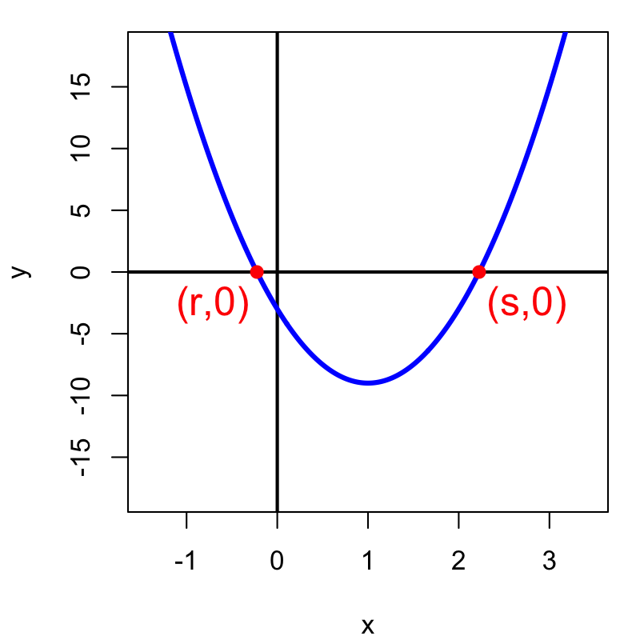

By using the [quadratic formula](https://en.wikipedia.org/wiki/Quadratic_formula), find the roots.

- $r=$
- $s=$

Identify the parameters.

- The quadratic coefficient: $a=6$
- The linear coefficient: $b=-12$
- The constant: $c=-3$

The $x$-intercepts of a function are found by solving for $x$ when $f(x)=0$.

$$6x^2-12x-3=0$$

Use the quadratic formula to solve the equation.

$$x~=~\frac{-(-12)\pm
\sqrt{(-12)^2-4(6)(-3)}}{2(6)}$$

Simplify.

$$x~=~\frac{12\pm \sqrt{144
+72}}{12}$$

Simplify MORE.

$$x~=~\frac{12\pm
\sqrt{216}}{12}$$

Now, plug both expressions into a calculator.

$$x~=~\frac{12-
\sqrt{216}}{12}~=~-0.2247449 ~\approx -0.22$$

OR

$$x~=~\frac{12+
\sqrt{216}}{12}~=~2.2247449 ~\approx 2.22$$

So, $r=-0.2247449$ and $s=2.2247449$.

Consider the quadratic function defined below:

$$f(x)~=~-4x^2-2x+11$$

When we graph $y=f(x)$, we see there are two [roots](https://en.wikipedia.org/wiki/Zero_of_a_function) at $(r,0)$ and $(s,0)$. (The word "roots" means the same thing as "$x$-intercepts" or "zeros".)

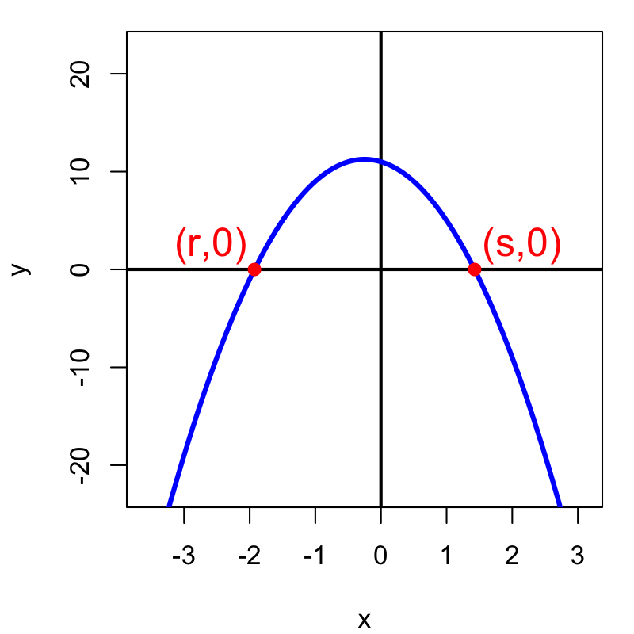

By using the [quadratic formula](https://en.wikipedia.org/wiki/Quadratic_formula), find the roots.

- $r=$
- $s=$

Identify the parameters.

- The quadratic coefficient: $a=-4$
- The linear coefficient: $b=-2$
- The constant: $c=11$

The $x$-intercepts of a function are found by solving for $x$ when $f(x)=0$.

$$-4x^2-2x+11=0$$

Use the quadratic formula to solve the equation.

$$x~=~\frac{-(-2)\pm
\sqrt{(-2)^2-4(-4)(11)}}{2(-4)}$$

Simplify.

$$x~=~\frac{2\pm \sqrt{4
+176}}{-8}$$

Simplify MORE.

$$x~=~\frac{2\pm
\sqrt{180}}{-8}$$

Now, plug both expressions into a calculator.

$$x~=~\frac{2- \sqrt{180}}{-8}~=~1.427051
~\approx 1.43$$

OR

$$x~=~\frac{2+ \sqrt{180}}{-8}~=~-1.927051
~\approx -1.93$$

So, $r=-1.927051$ and $s=1.427051$.

A [quadratic function](https://en.wikipedia.org/wiki/Quadratic_function) is graphed below. Notice the curve is a [parabola](https://en.wikipedia.org/wiki/Parabola) with a vertical axis of symmetry.

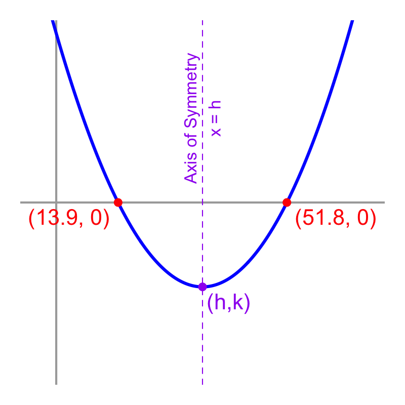

Notice the axis of symmetry intersects with the parabola at the vertex. We will typically use $h$ to represent the horizontal coordinate of the vertex and $k$ to represent the vertical coordinate of the vertex. Thus the vertex is at the point $(h,k)$ and the line of symmetry can be represented with the line $x=h$.

As shown in the graph, the parabola has roots at $13.9$ and $51.8$.

Find the value of $h$.

You can simply find the mean (average) of the two roots.

$$h=\frac{13.9+51.8}{2}$$

$$h=32.85$$

A [quadratic function](https://en.wikipedia.org/wiki/Quadratic_function) is graphed below. Notice the curve is a [parabola](https://en.wikipedia.org/wiki/Parabola) with a vertical axis of symmetry.

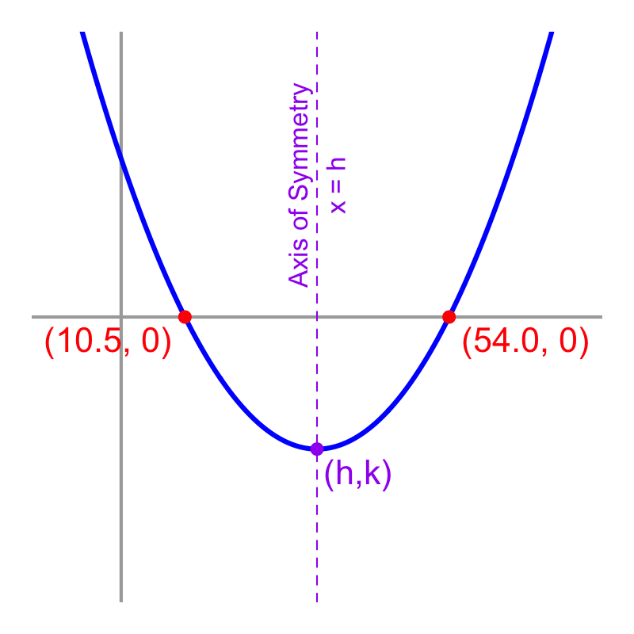

Notice the axis of symmetry intersects with the parabola at the vertex. We will typically use $h$ to represent the horizontal coordinate of the vertex and $k$ to represent the vertical coordinate of the vertex. Thus the vertex is at the point $(h,k)$ and the line of symmetry can be represented with the line $x=h$.

As shown in the graph, the parabola has roots at $10.5$ and $54.0$.

Find the value of $h$.

You can simply find the mean (average) of the two roots.

$$h=\frac{10.5+54.0}{2}$$

$$h=32.25$$

A [quadratic function](https://en.wikipedia.org/wiki/Quadratic_function) is graphed below. Notice the curve is a [parabola](https://en.wikipedia.org/wiki/Parabola) with a vertical axis of symmetry.

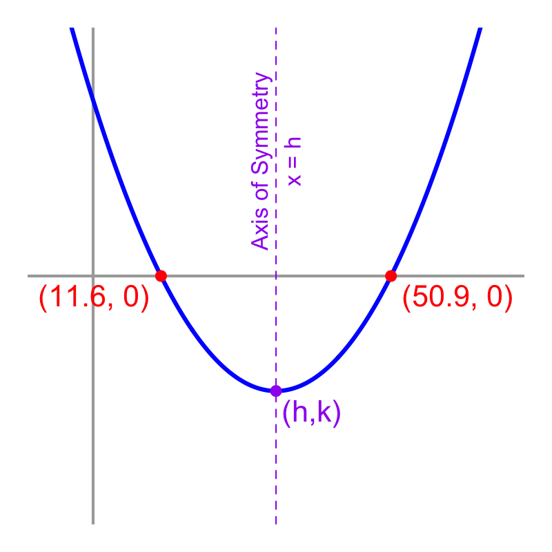

Notice the axis of symmetry intersects with the parabola at the vertex. We will typically use $h$ to represent the horizontal coordinate of the vertex and $k$ to represent the vertical coordinate of the vertex. Thus the vertex is at the point $(h,k)$ and the line of symmetry can be represented with the line $x=h$.

As shown in the graph, the parabola has roots at $11.6$ and $50.9$.

Find the value of $h$.

You can simply find the mean (average) of the two roots.

$$h=\frac{11.6+50.9}{2}$$

$$h=31.25$$

A [quadratic function](https://en.wikipedia.org/wiki/Quadratic_function) is graphed below. Notice the curve is a [parabola](https://en.wikipedia.org/wiki/Parabola) with a vertical axis of symmetry.

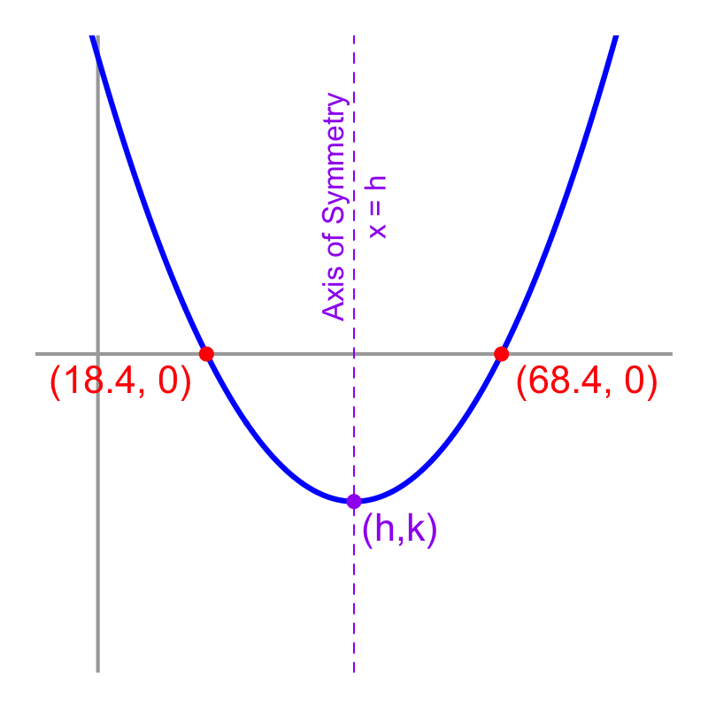

Notice the axis of symmetry intersects with the parabola at the vertex. We will typically use $h$ to represent the horizontal coordinate of the vertex and $k$ to represent the vertical coordinate of the vertex. Thus the vertex is at the point $(h,k)$ and the line of symmetry can be represented with the line $x=h$.

As shown in the graph, the parabola has roots at $18.4$ and $68.4$.

Find the value of $h$.

You can simply find the mean (average) of the two roots.

$$h=\frac{18.4+68.4}{2}$$

$$h=43.40$$

A [quadratic function](https://en.wikipedia.org/wiki/Quadratic_function) is graphed below. Notice the curve is a [parabola](https://en.wikipedia.org/wiki/Parabola) with a vertical axis of symmetry.

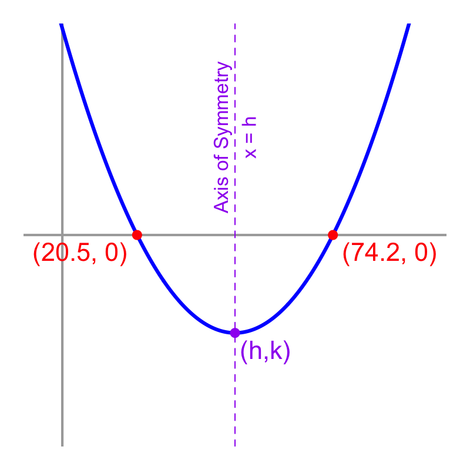

Notice the axis of symmetry intersects with the parabola at the vertex. We will typically use $h$ to represent the horizontal coordinate of the vertex and $k$ to represent the vertical coordinate of the vertex. Thus the vertex is at the point $(h,k)$ and the line of symmetry can be represented with the line $x=h$.

As shown in the graph, the parabola has roots at $20.5$ and $74.2$.

Find the value of $h$.

You can simply find the mean (average) of the two roots.

$$h=\frac{20.5+74.2}{2}$$

$$h=47.35$$

A [quadratic function](https://en.wikipedia.org/wiki/Quadratic_function) is graphed below. Notice the curve is a [parabola](https://en.wikipedia.org/wiki/Parabola) with a vertical axis of symmetry.

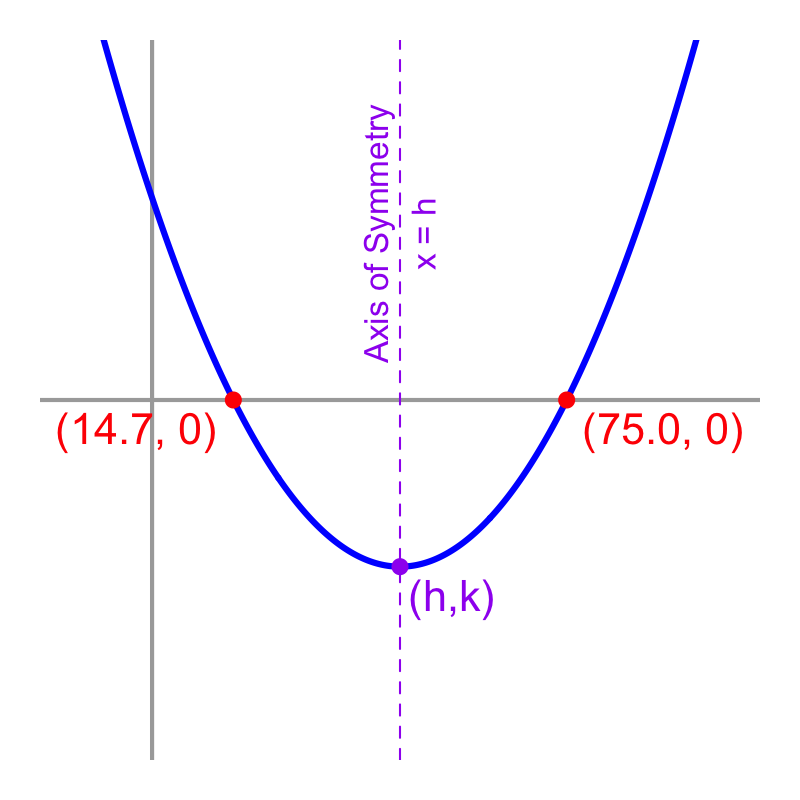

Notice the axis of symmetry intersects with the parabola at the vertex. We will typically use $h$ to represent the horizontal coordinate of the vertex and $k$ to represent the vertical coordinate of the vertex. Thus the vertex is at the point $(h,k)$ and the line of symmetry can be represented with the line $x=h$.

As shown in the graph, the parabola has roots at $14.7$ and $75.0$.

Find the value of $h$.

You can simply find the mean (average) of the two roots.

$$h=\frac{14.7+75.0}{2}$$

$$h=44.85$$

A [quadratic function](https://en.wikipedia.org/wiki/Quadratic_function) is graphed below. Notice the curve is a [parabola](https://en.wikipedia.org/wiki/Parabola) with a vertical axis of symmetry.

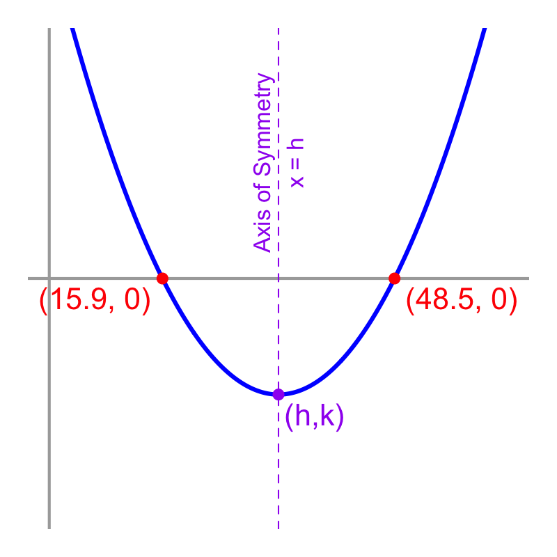

Notice the axis of symmetry intersects with the parabola at the vertex. We will typically use $h$ to represent the horizontal coordinate of the vertex and $k$ to represent the vertical coordinate of the vertex. Thus the vertex is at the point $(h,k)$ and the line of symmetry can be represented with the line $x=h$.

As shown in the graph, the parabola has roots at $15.9$ and $48.5$.

Find the value of $h$.

You can simply find the mean (average) of the two roots.

$$h=\frac{15.9+48.5}{2}$$

$$h=32.20$$

A [quadratic function](https://en.wikipedia.org/wiki/Quadratic_function) is graphed below. Notice the curve is a [parabola](https://en.wikipedia.org/wiki/Parabola) with a vertical axis of symmetry.

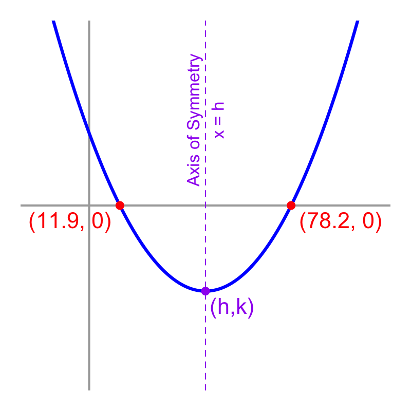

Notice the axis of symmetry intersects with the parabola at the vertex. We will typically use $h$ to represent the horizontal coordinate of the vertex and $k$ to represent the vertical coordinate of the vertex. Thus the vertex is at the point $(h,k)$ and the line of symmetry can be represented with the line $x=h$.

As shown in the graph, the parabola has roots at $11.9$ and $78.2$.

Find the value of $h$.

You can simply find the mean (average) of the two roots.

$$h=\frac{11.9+78.2}{2}$$

$$h=45.05$$

A [quadratic function](https://en.wikipedia.org/wiki/Quadratic_function) is graphed below. Notice the curve is a [parabola](https://en.wikipedia.org/wiki/Parabola) with a vertical axis of symmetry and roots at $15.2$ and $87.2$ .

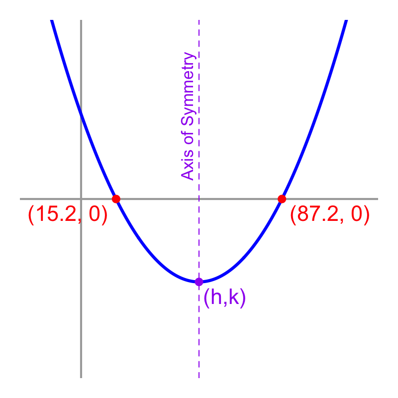

What is the equation for the axis of symmetry?

$x=50.6$$y=50.6$$x=50.9$$y=50.9$$x=51.2$$y=51.2$$x=51.5$$y=51.5$$x=51.8$$y=51.8$

You can simply find the mean of the two roots.

$$h=\frac{15.2+87.2}{2}$$

$$h=51.20$$

The axis of symmetry is a vertical line, so it is represented by an equation in which $x$ equals a constant.

$$\text{Axis of
Symmetry:}~~~x=51.2$$

A [quadratic function](https://en.wikipedia.org/wiki/Quadratic_function) is graphed below. Notice the curve is a [parabola](https://en.wikipedia.org/wiki/Parabola) with a vertical axis of symmetry and roots at $19.7$ and $82.7$ .

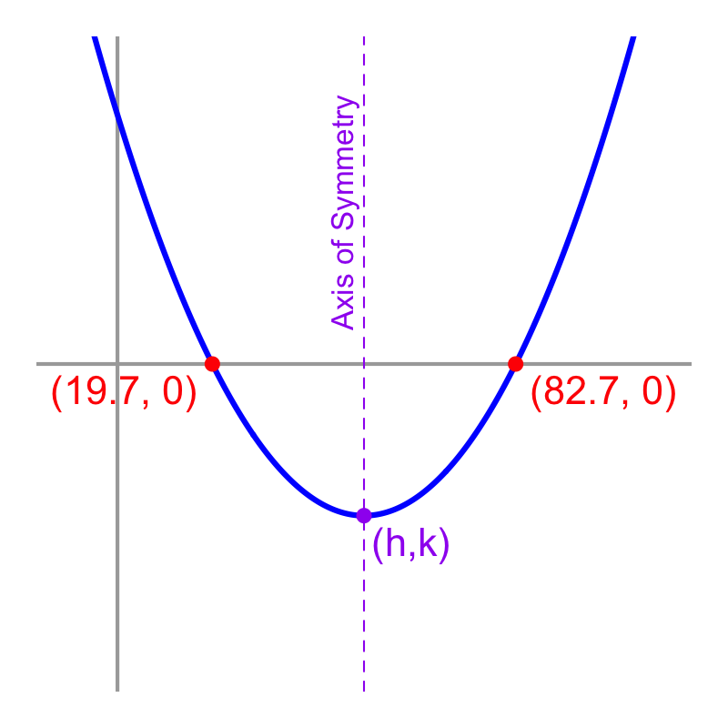

What is the equation for the axis of symmetry?

$x=50.3$$y=50.3$$x=50.6$$y=50.6$$x=50.9$$y=50.9$$x=51.2$$y=51.2$$x=51.5$$y=51.5$

You can simply find the mean of the two roots.

$$h=\frac{19.7+82.7}{2}$$

$$h=51.20$$

The axis of symmetry is a vertical line, so it is represented by an equation in which $x$ equals a constant.

$$\text{Axis of
Symmetry:}~~~x=51.2$$

A [quadratic function](https://en.wikipedia.org/wiki/Quadratic_function) is graphed below. Notice the curve is a [parabola](https://en.wikipedia.org/wiki/Parabola) with a vertical axis of symmetry and roots at $18.4$ and $84.0$ .

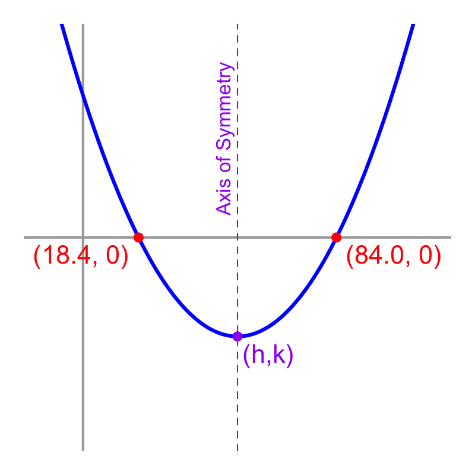

What is the equation for the axis of symmetry?

$x=50.3$$y=50.3$$x=50.6$$y=50.6$$x=50.9$$y=50.9$$x=51.2$$y=51.2$$x=51.5$$y=51.5$

You can simply find the mean of the two roots.

$$h=\frac{18.4+84.0}{2}$$

$$h=51.20$$

The axis of symmetry is a vertical line, so it is represented by an equation in which $x$ equals a constant.

$$\text{Axis of
Symmetry:}~~~x=51.2$$

A [quadratic function](https://en.wikipedia.org/wiki/Quadratic_function) is graphed below. Notice the curve is a [parabola](https://en.wikipedia.org/wiki/Parabola) with a vertical axis of symmetry and roots at $18.9$ and $83.5$ .

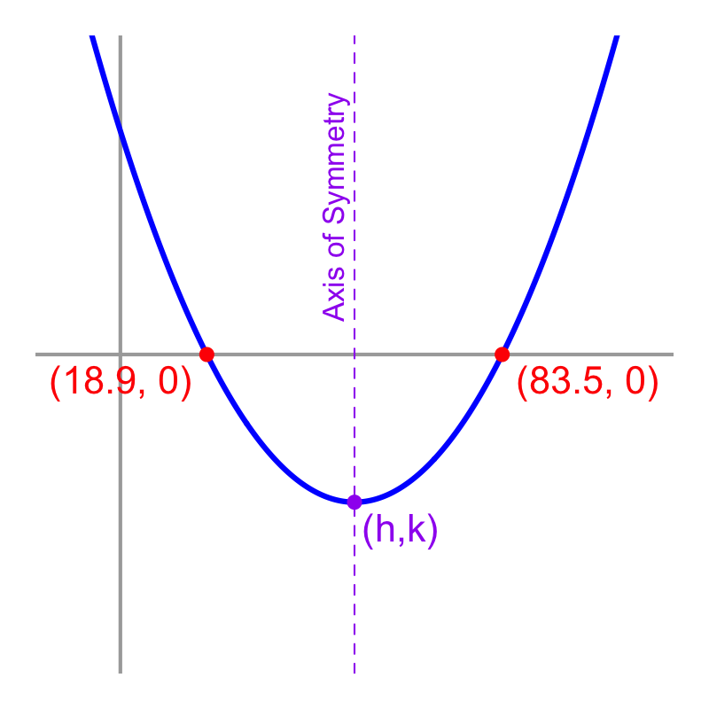

What is the equation for the axis of symmetry?

$x=50.3$$y=50.3$$x=50.6$$y=50.6$$x=50.9$$y=50.9$$x=51.2$$y=51.2$$x=51.5$$y=51.5$

You can simply find the mean of the two roots.

$$h=\frac{18.9+83.5}{2}$$

$$h=51.20$$

The axis of symmetry is a vertical line, so it is represented by an equation in which $x$ equals a constant.

$$\text{Axis of
Symmetry:}~~~x=51.2$$

A [quadratic function](https://en.wikipedia.org/wiki/Quadratic_function) is graphed below. Notice the curve is a [parabola](https://en.wikipedia.org/wiki/Parabola) with a vertical axis of symmetry and roots at $11.6$ and $39.6$ .

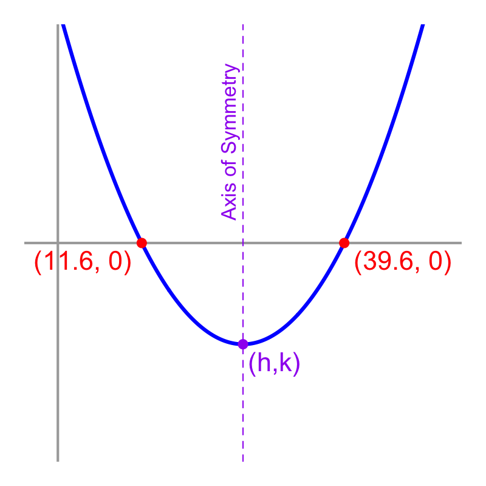

What is the equation for the axis of symmetry?

$x=24.4$$y=24.4$$x=24.7$$y=24.7$$x=25.0$$y=25.0$$x=25.3$$y=25.3$$x=25.6$$y=25.6$

You can simply find the mean of the two roots.

$$h=\frac{11.6+39.6}{2}$$

$$h=25.60$$

The axis of symmetry is a vertical line, so it is represented by an equation in which $x$ equals a constant.

$$\text{Axis of
Symmetry:}~~~x=25.6$$

A [quadratic function](https://en.wikipedia.org/wiki/Quadratic_function) is graphed below. Notice the curve is a [parabola](https://en.wikipedia.org/wiki/Parabola) with a vertical axis of symmetry and roots at $16.6$ and $85.8$ .

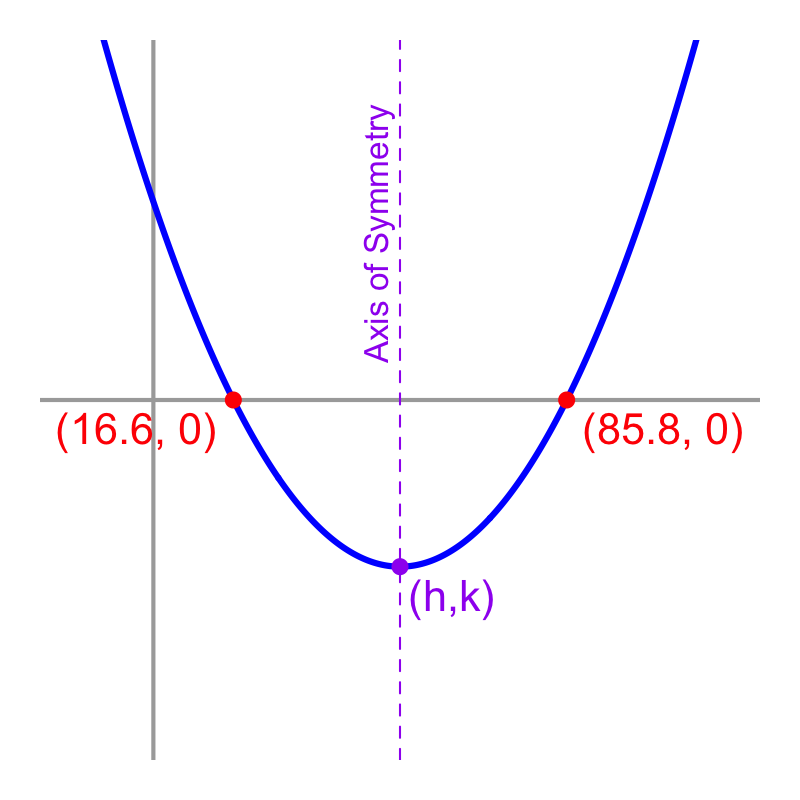

What is the equation for the axis of symmetry?

$x=51.2$$y=51.2$$x=51.5$$y=51.5$$x=51.8$$y=51.8$$x=52.1$$y=52.1$$x=52.4$$y=52.4$

You can simply find the mean of the two roots.

$$h=\frac{16.6+85.8}{2}$$

$$h=51.20$$

The axis of symmetry is a vertical line, so it is represented by an equation in which $x$ equals a constant.

$$\text{Axis of
Symmetry:}~~~x=51.2$$

A [quadratic function](https://en.wikipedia.org/wiki/Quadratic_function) is graphed below. Notice the curve is a [parabola](https://en.wikipedia.org/wiki/Parabola) with a vertical axis of symmetry and roots at $21.5$ and $80.9$ .

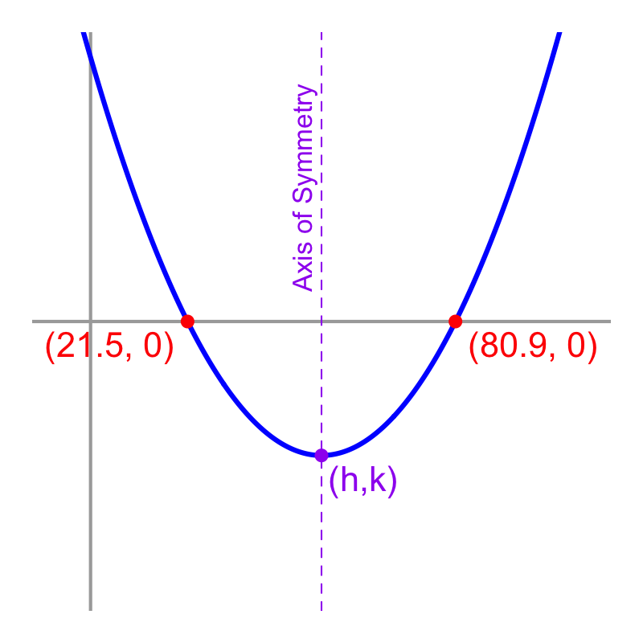

What is the equation for the axis of symmetry?

$x=50.0$$y=50.0$$x=50.3$$y=50.3$$x=50.6$$y=50.6$$x=50.9$$y=50.9$$x=51.2$$y=51.2$

You can simply find the mean of the two roots.

$$h=\frac{21.5+80.9}{2}$$

$$h=51.20$$

The axis of symmetry is a vertical line, so it is represented by an equation in which $x$ equals a constant.

$$\text{Axis of
Symmetry:}~~~x=51.2$$

A [quadratic function](https://en.wikipedia.org/wiki/Quadratic_function) is graphed below. Notice the curve is a [parabola](https://en.wikipedia.org/wiki/Parabola) with a vertical axis of symmetry and roots at $14.0$ and $88.4$ .

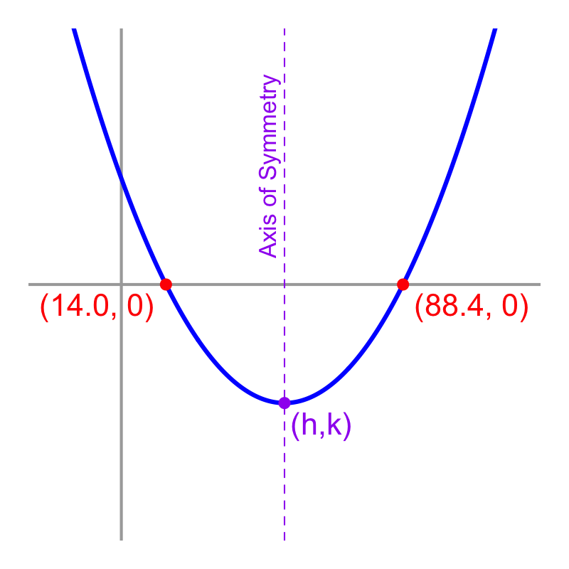

What is the equation for the axis of symmetry?

$x=51.2$$y=51.2$$x=51.5$$y=51.5$$x=51.8$$y=51.8$$x=52.1$$y=52.1$$x=52.4$$y=52.4$

You can simply find the mean of the two roots.

$$h=\frac{14.0+88.4}{2}$$

$$h=51.20$$

The axis of symmetry is a vertical line, so it is represented by an equation in which $x$ equals a constant.

$$\text{Axis of
Symmetry:}~~~x=51.2$$

A [quadratic function](https://en.wikipedia.org/wiki/Quadratic_function) is graphed below. Notice the curve is a [parabola](https://en.wikipedia.org/wiki/Parabola) with a vertical axis of symmetry.

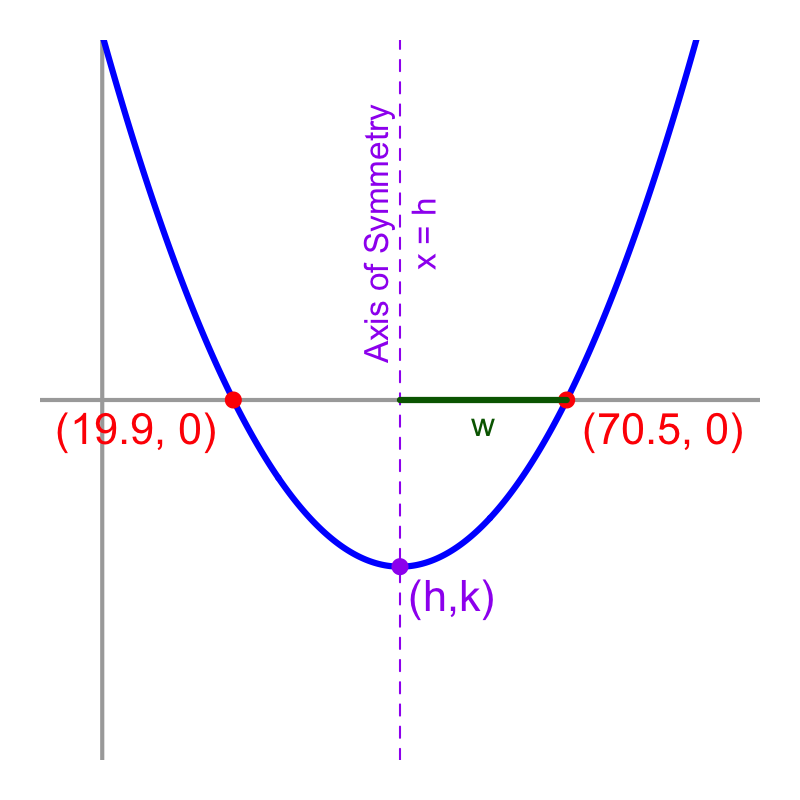

As shown in the graph, the parabola has roots at $19.9$ and $70.5$. I've marked the vertex with $(h,k)$ and the distance from the axis of symmetry to a root with $w$.

Find $w$.

You can simply find half the difference of the roots.

$$h=\frac{19.9-70.5}{2}$$

$$w=25.3$$

A [quadratic function](https://en.wikipedia.org/wiki/Quadratic_function) is graphed below. Notice the curve is a [parabola](https://en.wikipedia.org/wiki/Parabola) with a vertical axis of symmetry.

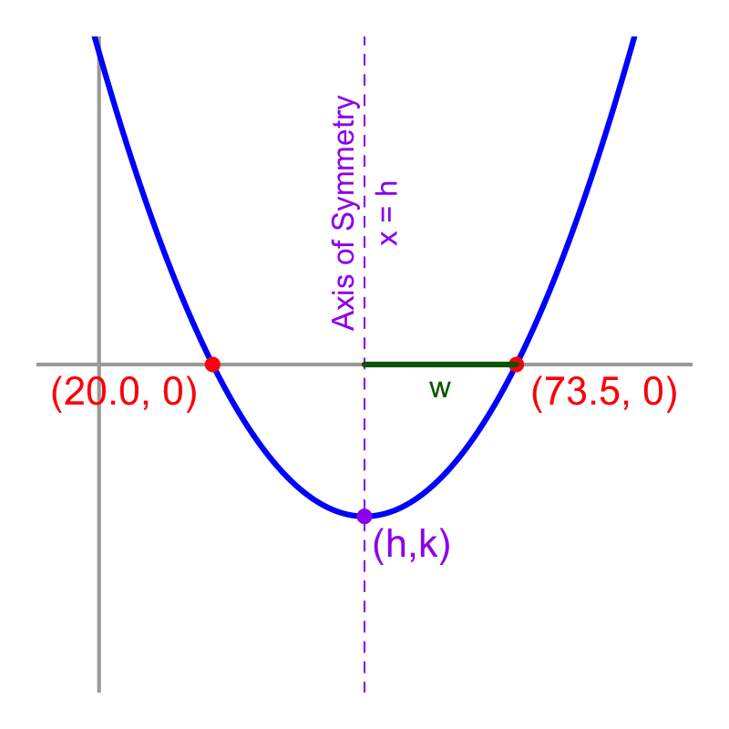

As shown in the graph, the parabola has roots at $20.0$ and $73.5$. I've marked the vertex with $(h,k)$ and the distance from the axis of symmetry to a root with $w$.

Find $w$.

You can simply find half the difference of the roots.

$$h=\frac{20.0-73.5}{2}$$

$$w=26.75$$

A [quadratic function](https://en.wikipedia.org/wiki/Quadratic_function) is graphed below. Notice the curve is a [parabola](https://en.wikipedia.org/wiki/Parabola) with a vertical axis of symmetry.

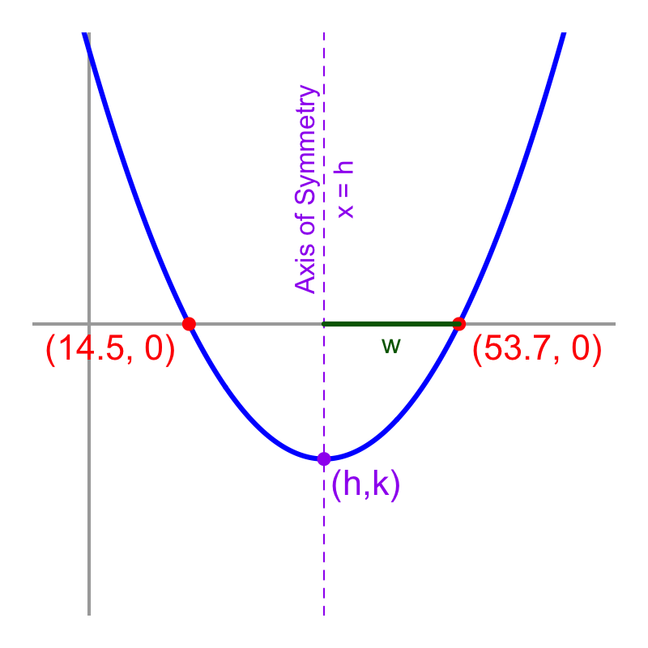

As shown in the graph, the parabola has roots at $14.5$ and $53.7$. I've marked the vertex with $(h,k)$ and the distance from the axis of symmetry to a root with $w$.

Find $w$.

You can simply find half the difference of the roots.

$$h=\frac{14.5-53.7}{2}$$

$$w=19.6$$

A [quadratic function](https://en.wikipedia.org/wiki/Quadratic_function) is graphed below. Notice the curve is a [parabola](https://en.wikipedia.org/wiki/Parabola) with a vertical axis of symmetry.

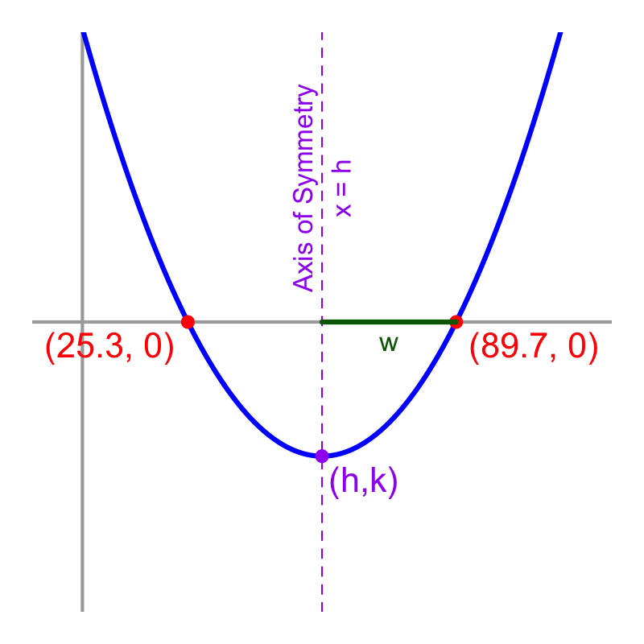

As shown in the graph, the parabola has roots at $25.3$ and $89.7$. I've marked the vertex with $(h,k)$ and the distance from the axis of symmetry to a root with $w$.

Find $w$.

You can simply find half the difference of the roots.

$$h=\frac{25.3-89.7}{2}$$

$$w=32.2$$

A [quadratic function](https://en.wikipedia.org/wiki/Quadratic_function) is graphed below. Notice the curve is a [parabola](https://en.wikipedia.org/wiki/Parabola) with a vertical axis of symmetry.

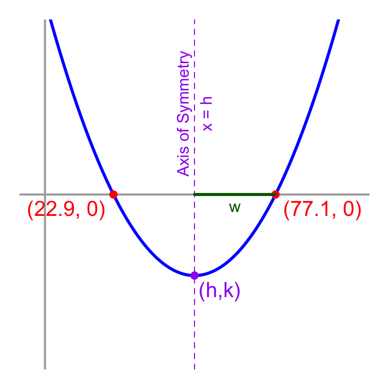

As shown in the graph, the parabola has roots at $22.9$ and $77.1$. I've marked the vertex with $(h,k)$ and the distance from the axis of symmetry to a root with $w$.

Find $w$.

You can simply find half the difference of the roots.

$$h=\frac{22.9-77.1}{2}$$

$$w=27.1$$

A [quadratic function](https://en.wikipedia.org/wiki/Quadratic_function) is graphed below. Notice the curve is a [parabola](https://en.wikipedia.org/wiki/Parabola) with a vertical axis of symmetry.

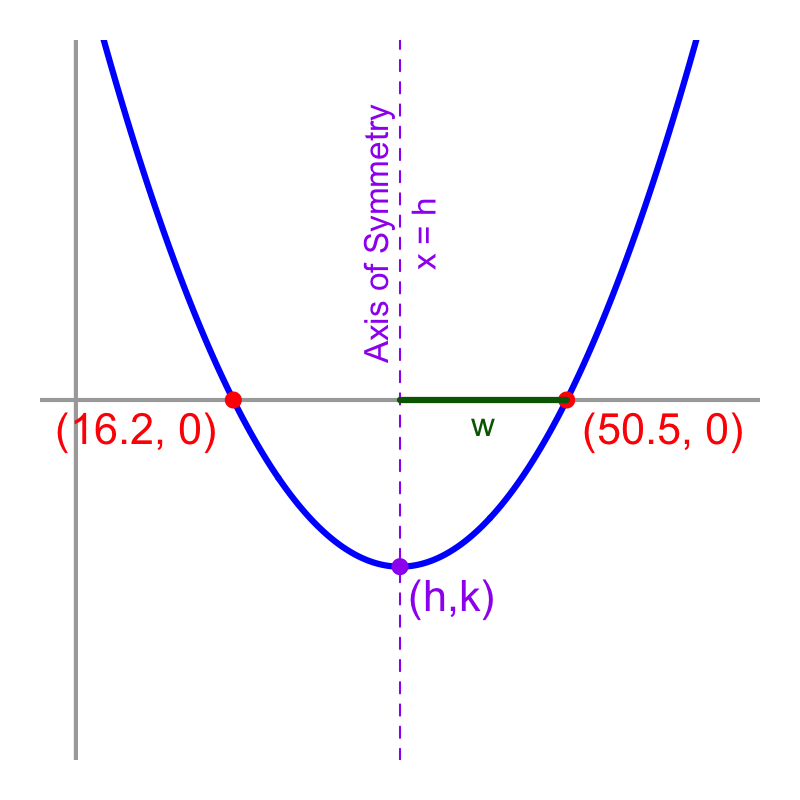

As shown in the graph, the parabola has roots at $16.2$ and $50.5$. I've marked the vertex with $(h,k)$ and the distance from the axis of symmetry to a root with $w$.